# TimeSeries_Ecommerce_Forecasting

jennifer siwu

7/8/2020

# Reading the data

The dataset came from 3 different tables: orders, order items, and items. From the order table, we need to get the dates based on the order purchase date because in demand planning perspective, the order starts from that point. In other words, in demand planning realm, we should have the inventory based on the customer purchase date.

```r
ord_df <- read.csv("~/Desktop/MSBA/Winter 2020/Bus Data Mgmt/brazilian-ecommerce/olist_orders_dataset.csv", header=TRUE)
oi_df <- read.csv("~/Desktop/MSBA/Winter 2020/Bus Data Mgmt/brazilian-ecommerce/olist_order_items_dataset.csv", header=TRUE)
itm_df <- read.csv("~/Desktop/MSBA/Winter 2020/Bus Data Mgmt/brazilian-ecommerce/olist_products_dataset.csv", header=TRUE)
itm_eng_df <- read.csv("~/Desktop/MSBA/Winter 2020/Bus Data Mgmt/brazilian-ecommerce/product_category_name_translation.csv", header=TRUE)
```

```r
#str(ord_df)
#str(oi_df)
#str(itm_df)

head(ord_df)
```

```
##                           order_id                      customer_id
## 1 e481f51cbdc54678b7cc49136f2d6af7 9ef432eb6251297304e76186b10a928d
## 2 53cdb2fc8bc7dce0b6741e2150273451 b0830fb4747a6c6d20dea0b8c802d7ef
## 3 47770eb9100c2d0c44946d9cf07ec65d 41ce2a54c0b03bf3443c3d931a367089
## 4 949d5b44dbf5de918fe9c16f97b45f8a f88197465ea7920adcdbec7375364d82
## 5 ad21c59c0840e6cb83a9ceb5573f8159 8ab97904e6daea8866dbdbc4fb7aad2c
## 6 a4591c265e18cb1dcee52889e2d8acc3 503740e9ca751ccdda7ba28e9ab8f608
##   order_status order_purchase_timestamp   order_approved_at
## 1    delivered      2017-10-02 10:56:33 2017-10-02 11:07:15
## 2    delivered      2018-07-24 20:41:37 2018-07-26 03:24:27
## 3    delivered      2018-08-08 08:38:49 2018-08-08 08:55:23
## 4    delivered      2017-11-18 19:28:06 2017-11-18 19:45:59
## 5    delivered      2018-02-13 21:18:39 2018-02-13 22:20:29
## 6    delivered      2017-07-09 21:57:05 2017-07-09 22:10:13
##   order_delivered_carrier_date order_delivered_customer_date
## 1          2017-10-04 19:55:00           2017-10-10 21:25:13
## 2          2018-07-26 14:31:00           2018-08-07 15:27:45
## 3          2018-08-08 13:50:00           2018-08-17 18:06:29
## 4          2017-11-22 13:39:59           2017-12-02 00:28:42
## 5          2018-02-14 19:46:34           2018-02-16 18:17:02
## 6          2017-07-11 14:58:04           2017-07-26 10:57:55
##   order_estimated_delivery_date
## 1           2017-10-18 00:00:00
## 2           2018-08-13 00:00:00
## 3           2018-09-04 00:00:00
## 4           2017-12-15 00:00:00
## 5           2018-02-26 00:00:00
## 6           2017-08-01 00:00:00
```

```r
head(oi_df)
```

```
##                           order_id order_item_id
## 1 00010242fe8c5a6d1ba2dd792cb16214             1
## 2 00018f77f2f0320c557190d7a144bdd3             1
## 3 000229ec398224ef6ca0657da4fc703e             1
## 4 00024acbcdf0a6daa1e931b038114c75             1
## 5 00042b26cf59d7ce69dfabb4e55b4fd9             1
## 6 00048cc3ae777c65dbb7d2a0634bc1ea             1
##                         product_id                        seller_id
## 1 4244733e06e7ecb4970a6e2683c13e61 48436dade18ac8b2bce089ec2a041202
## 2 e5f2d52b802189ee658865ca93d83a8f dd7ddc04e1b6c2c614352b383efe2d36
## 3 c777355d18b72b67abbeef9df44fd0fd 5b51032eddd242adc84c38acab88f23d
## 4 7634da152a4610f1595efa32f14722fc 9d7a1d34a5052409006425275ba1c2b4
## 5 ac6c3623068f30de03045865e4e10089 df560393f3a51e74553ab94004ba5c87
## 6 ef92defde845ab8450f9d70c526ef70f 6426d21aca402a131fc0a5d0960a3c90
##   shipping_limit_date  price freight_value
## 1 2017-09-19 09:45:35  58.90         13.29
## 2 2017-05-03 11:05:13 239.90         19.93
## 3 2018-01-18 14:48:30 199.00         17.87
## 4 2018-08-15 10:10:18  12.99         12.79
## 5 2017-02-13 13:57:51 199.90         18.14
## 6 2017-05-23 03:55:27  21.90         12.69
```

```r
head(itm_df)
```

```
##                         product_id product_category_name product_name_lenght
## 1 1e9e8ef04dbcff4541ed26657ea517e5            perfumaria                  40
## 2 3aa071139cb16b67ca9e5dea641aaa2f                 artes                  44
## 3 96bd76ec8810374ed1b65e291975717f         esporte_lazer                  46
## 4 cef67bcfe19066a932b7673e239eb23d                 bebes                  27
## 5 9dc1a7de274444849c219cff195d0b71 utilidades_domesticas                  37
## 6 41d3672d4792049fa1779bb35283ed13 instrumentos_musicais                  60
##   product_description_lenght product_photos_qty product_weight_g
## 1                        287                  1              225
## 2                        276                  1             1000
## 3                        250                  1              154
## 4                        261                  1              371
## 5                        402                  4              625
## 6                        745                  1              200
##   product_length_cm product_height_cm product_width_cm
## 1                16                10               14
## 2                30                18               20
## 3                18                 9               15
## 4                26                 4               26
## 5                20                17               13
## 6                38                 5               11
```

```r
head(itm_eng_df)
```

```
##    product_category_name product_category_name_english
## 1           beleza_saude                 health_beauty
## 2 informatica_acessorios         computers_accessories
## 3             automotivo                          auto
## 4        cama_mesa_banho                bed_bath_table
## 5       moveis_decoracao               furniture_decor
## 6          esporte_lazer                sports_leisure
```

# Merging The data

First, Let’s combine the product name and category name translation together.

```r
product_complete <- left_join(itm_df, itm_eng_df, by = "product_category_name", copy = FALSE)

items_df <-
  product_complete  %>% dplyr::select(product_id,
           product_category_name,
           product_category_name_english) %>%
               mutate(product_category_name_english =ifelse(is.null(product_category_name_english)
                                                            & product_category_name == "pc_gamer","pc_gamer",
                                                      ifelse(is.null(product_category_name_english)
                                                             & product_category_name != "pc_gamer","portable_mixer",
                                                             product_category_name_english)
                                                      )) %>%
                                                      dplyr::select(product_id,product_category_name_english)

head(items_df)
```

```
##                         product_id product_category_name_english
## 1 1e9e8ef04dbcff4541ed26657ea517e5                     perfumery
## 2 3aa071139cb16b67ca9e5dea641aaa2f                           art
## 3 96bd76ec8810374ed1b65e291975717f                sports_leisure
## 4 cef67bcfe19066a932b7673e239eb23d                          baby
## 5 9dc1a7de274444849c219cff195d0b71                    housewares
## 6 41d3672d4792049fa1779bb35283ed13           musical_instruments
```

Now, let’s create the master datafile as a combination of all 3 tables (ord_df, oi_df, and items_df)

```r
order <- dplyr::select(ord_df, c(order_id,order_purchase_timestamp)) %>%
          mutate(order_purchase_timestamp=as.Date(order_purchase_timestamp))
order <- order[order$order_purchase_timestamp >= as.Date('2017-01-01') & order$order_purchase_timestamp < as.Date('2018-08-01'),]


orderitem <- oi_df %>%
              dplyr::select(order_id,order_item_id,product_id,price) %>%
              mutate(total_price = order_item_id*price,
                     qty  = order_item_id) %>% dplyr::select(-order_item_id)

master_df <- inner_join(inner_join(order,orderitem, by = "order_id", copy = FALSE),items_df, by = "product_id", copy = FALSE)
head(master_df)
```

```
##                           order_id order_purchase_timestamp
## 1 e481f51cbdc54678b7cc49136f2d6af7               2017-10-02
## 2 53cdb2fc8bc7dce0b6741e2150273451               2018-07-24
## 3 949d5b44dbf5de918fe9c16f97b45f8a               2017-11-18
## 4 ad21c59c0840e6cb83a9ceb5573f8159               2018-02-13
## 5 a4591c265e18cb1dcee52889e2d8acc3               2017-07-09
## 6 136cce7faa42fdb2cefd53fdc79a6098               2017-04-11
##                         product_id  price total_price qty
## 1 87285b34884572647811a353c7ac498a  29.99       29.99   1
## 2 595fac2a385ac33a80bd5114aec74eb8 118.70      118.70   1
## 3 d0b61bfb1de832b15ba9d266ca96e5b0  45.00       45.00   1
## 4 65266b2da20d04dbe00c5c2d3bb7859e  19.90       19.90   1
## 5 060cb19345d90064d1015407193c233d 147.90      147.90   1
## 6 a1804276d9941ac0733cfd409f5206eb  49.90       49.90   1
##   product_category_name_english
## 1                    housewares
## 2                     perfumery
## 3                      pet_shop
## 4                    stationery
## 5                          auto
## 6                          <NA>
```

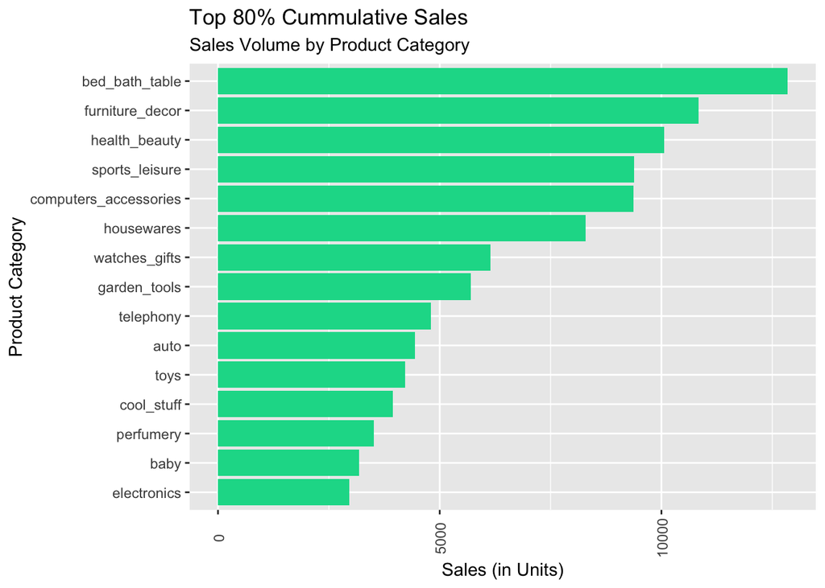

```r
tsdf <- master_df %>%
            group_by(order_purchase_timestamp,product_category_name_english) %>%
            summarise(sales_volume = sum(qty),
                      revenue = sum(total_price))

top_sales <- tsdf %>% group_by(product_category_name_english) %>%
              summarise(sales_volume = sum(sales_volume)) %>%  arrange(desc(sales_volume)) %>%
                    mutate(cummulative_sales = cumsum(sales_volume)/sum(tsdf$sales_volume))

top_rev <- tsdf %>% group_by(product_category_name_english) %>%
              summarise(revenue = sum(revenue)) %>%  arrange(desc(revenue)) %>%
                    mutate(cummulative_revenue = cumsum(revenue)/sum(tsdf$revenue))

top80sales <- top_sales[top_sales$cummulative_sales <= .8,] %>% arrange(cummulative_sales)
top80revenue <- top_rev[top_rev$cummulative_revenue <= .8,]


ggplot(top80sales, aes(x=reorder(product_category_name_english,-cummulative_sales))) +
  geom_bar(aes(y=sales_volume), fill='#06d997', stat="identity") +
  theme(axis.text.x = element_text(angle=90, vjust=0.6)) +
  labs(title = "Top 80% Cummulative Sales", subtitle = "Sales Volume by Product Category"
       , x = 'Product Category', y ='Sales (in Units)') + coord_flip()
```

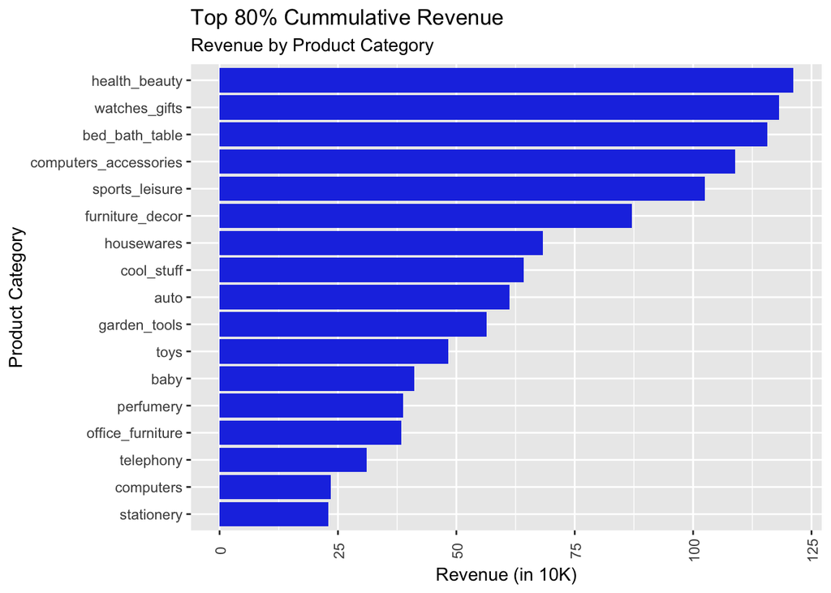

```r
ggplot(top80revenue, aes(x=reorder(product_category_name_english,-cummulative_revenue))) +
  geom_bar(aes(y=revenue/10000), fill='#213ee2', stat="identity") +
  theme(axis.text.x = element_text(angle=90, vjust=0.6)) +
  labs(title = "Top 80% Cummulative Revenue", subtitle = "Revenue by Product Category",
       x = 'Product Category', y ='Revenue (in 10K)')+  coord_flip()
```

# Looking at the overall time series trend

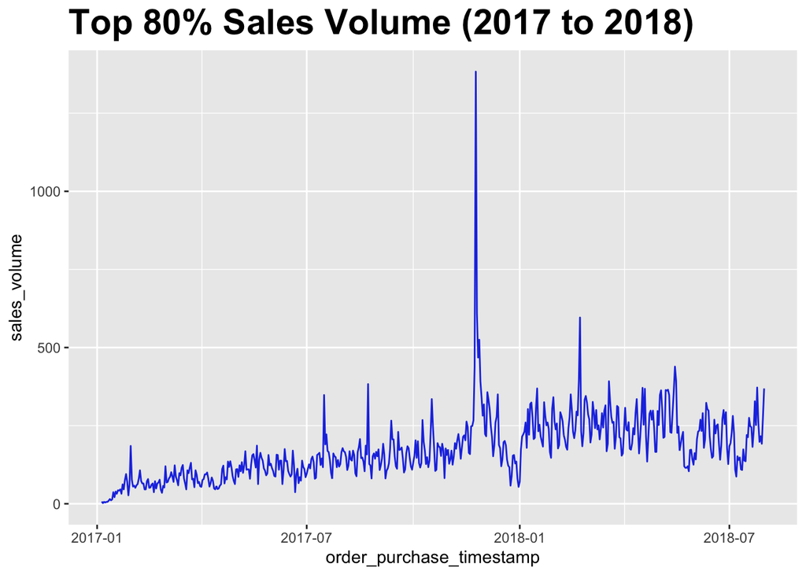

```r
tsdf2 <- master_df  %>% filter(product_category_name_english %in% top80sales$product_category_name_english) %>%
            group_by(order_purchase_timestamp) %>%
                summarise(sales_volume = sum(qty))
#ts(tsdf2$sales_volume, start = c(2016, 9, 4)) %>% autoplot()
p <- ggplot(tsdf2, aes(x=order_purchase_timestamp, y=sales_volume)) +
  geom_line(color = "#213ee2") +
  ggtitle("Top 80% Sales Volume (2017 to 2018)") +
  theme(plot.title = element_text(size = 22, face = "bold"))
p
```

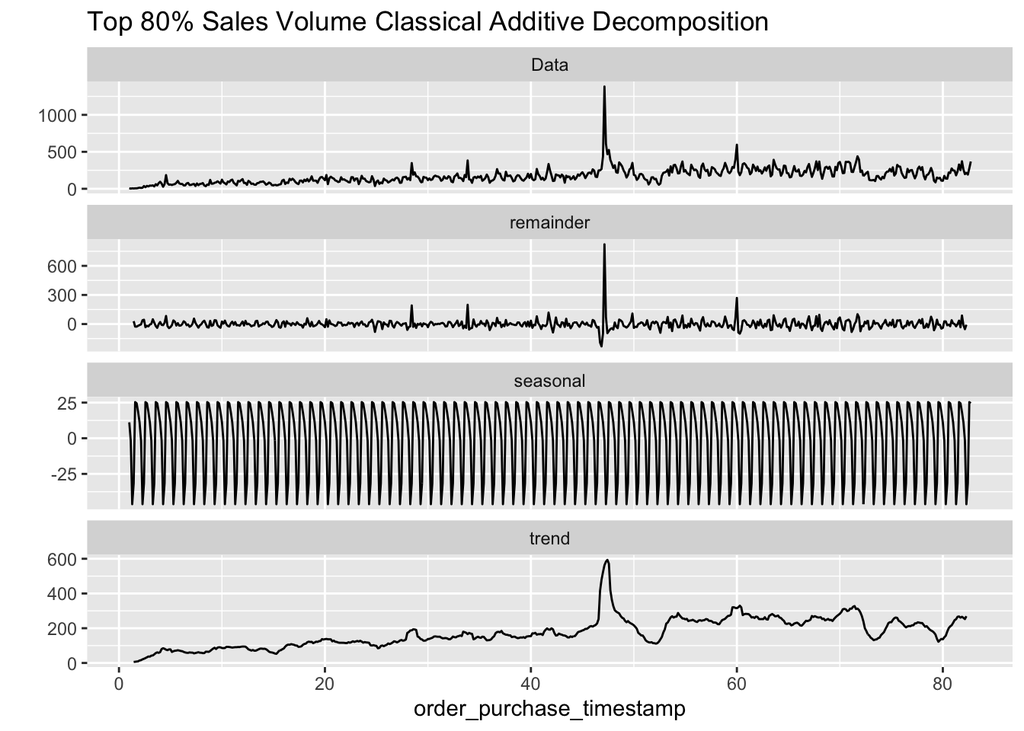

```r
dc1_classical_add <- decompose(ts(tsdf2$sales_volume, frequency = 7), type = "additive")
autoplot(dc1_classical_add) +
  ggtitle("Top 80% Sales Volume Classical Additive Decomposition") +
  xlab("order_purchase_timestamp")
```

# Time Series for Top 80% Sales Product Categories

Let’s zoom in on the time series a little bit to see the jump in black friday more closely based on each product category. Below is the time series plot for the top 3 product category. As we can see below, each product categories have different seasonality and they have different peak effect. With this analysis, I decided to do a bottom up forecast, meaning that I will create different models per each product category and sum it up at the end for the overall forecast. As for the items in each product category, I will allocate the forecast based on the their % of sales within the category, this is due to the idea that each product within the same category will more or less follow the same seasonality and trend.

For this analysis, I will focus only on the product categories that make up the top 80% Sales (~11M in Average Annual Revenue).

```r
tsdftemp <- tsdf[tsdf$product_category_name_english %in% top80sales$product_category_name_english,] %>%
  mutate(total_revenue = revenue*sales_volume)

sum(tsdftemp$total_revenue)/nrow(tsdftemp)*365
```

```
## [1] 11091130
```

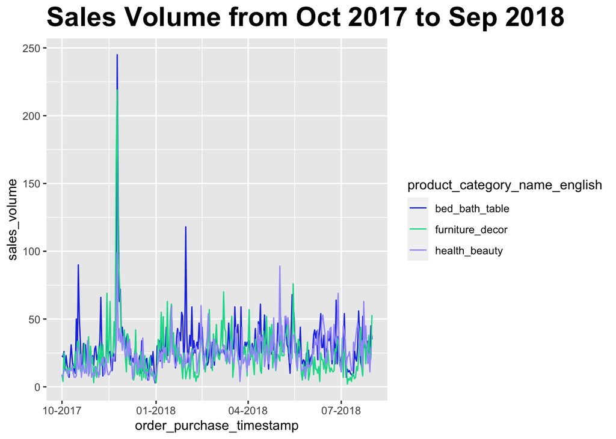

```r
tsdf2 <- select(tsdf,-revenue)[tsdf$product_category_name_english %in% c("bed_bath_table","furniture_decor"
                                                                         ,"health_beauty"),]

p <- ggplot(tsdf2[tsdf2$order_purchase_timestamp>= as.Date("2017-10-01"),], aes(x=order_purchase_timestamp, y=sales_volume, color = product_category_name_english)) +
  geom_line() +
  ggtitle("Sales Volume from Oct 2017 to Sep 2018") +
  scale_x_date(date_labels = "%m-%Y") +
  scale_color_manual(values=c("#213ee2", "#06d997","#a49cf8")) +
  theme(plot.title = element_text(size = 22, face = "bold"))
p
```

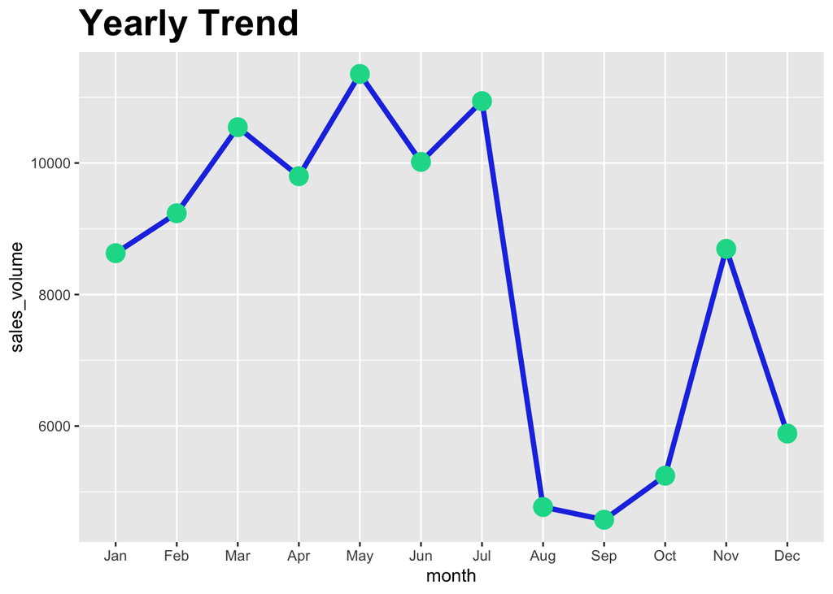

```r
tsdf80 <- tsdf[tsdf$product_category_name_english %in% top80sales$product_category_name_english,]
tsdf80f <- tsdf80 %>% mutate(dow = wday(order_purchase_timestamp, label=TRUE),
                             month = month(order_purchase_timestamp, label=TRUE),
                              day = day(order_purchase_timestamp))


monthtemp <- tsdf80f %>% group_by(month) %>% summarise(sales_volume= sum(sales_volume))

temp <- tsdf80f %>% group_by(dow) %>% summarise(sales_volume= sum(sales_volume))
temp$dow <- ordered(temp$dow, levels=c("Mon", "Tue", "Wed", "Thu", "Fri", "Sat", "Sun"))

daytemp <- tsdf80f %>% group_by(day) %>% summarise(sales_volume= sum(sales_volume))


ggplot(monthtemp, aes(x=month, y=sales_volume, group = 1)) +
  geom_line(color = "#213ee2",size=1.5) +
  geom_point(color = "#06d997",size=5)+
  ggtitle("Yearly Trend") +
  theme(plot.title = element_text(size = 22, face = "bold"))
```

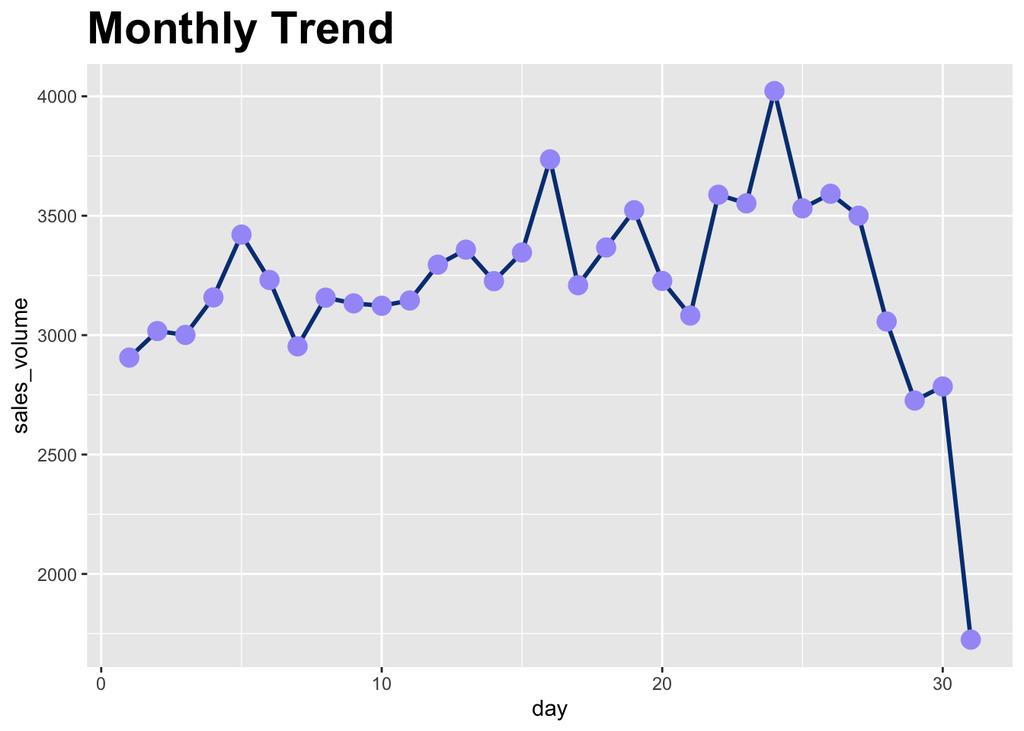

```r
ggplot(daytemp, aes(x=day, y=sales_volume, group = 1)) +
  geom_line(color = "#043e83",size=1) +
  geom_point(color = "#a49cf8",size=4)+
  ggtitle("Monthly Trend") +
  theme(plot.title = element_text(size = 22, face = "bold"))
```

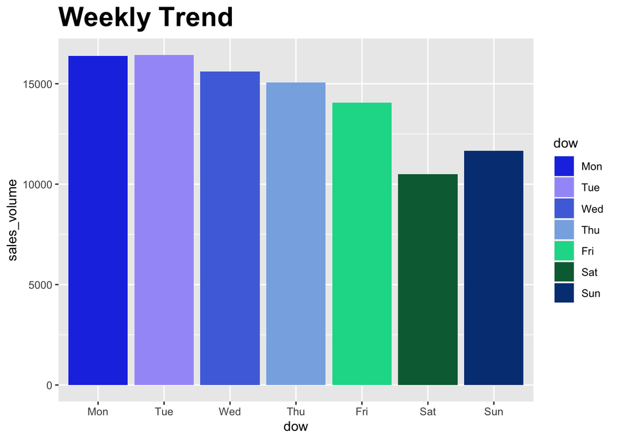

```r
ggplot(temp, aes(x=dow, y=sales_volume,fill=dow)) +
  geom_bar(position="dodge", stat="identity") +
  ggtitle("Weekly Trend") +
  scale_fill_manual(values=c("#213ee2","#a49cf8","#5071dd","#88b0e4","#06d997","#046a41","#043e83")) +
  theme(plot.title = element_text(size = 22, face = "bold"))
```

# Forecasting for Overall to Compare Models

## Arima, Sarima, Sarimax

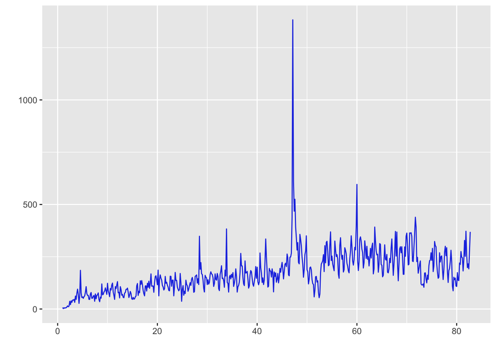

```r
#PACF & ACF showing so many lags correlated with the last values -->  Need to make data stationary
tsreg <- tsdf80f %>% group_by(order_purchase_timestamp) %>% summarise(sales_volume=sum(sales_volume))
tsregts <-  ts(tsreg$sales_volume, frequency = 7)
autoplot(tsregts, ts.colour = "#213ee2")
```

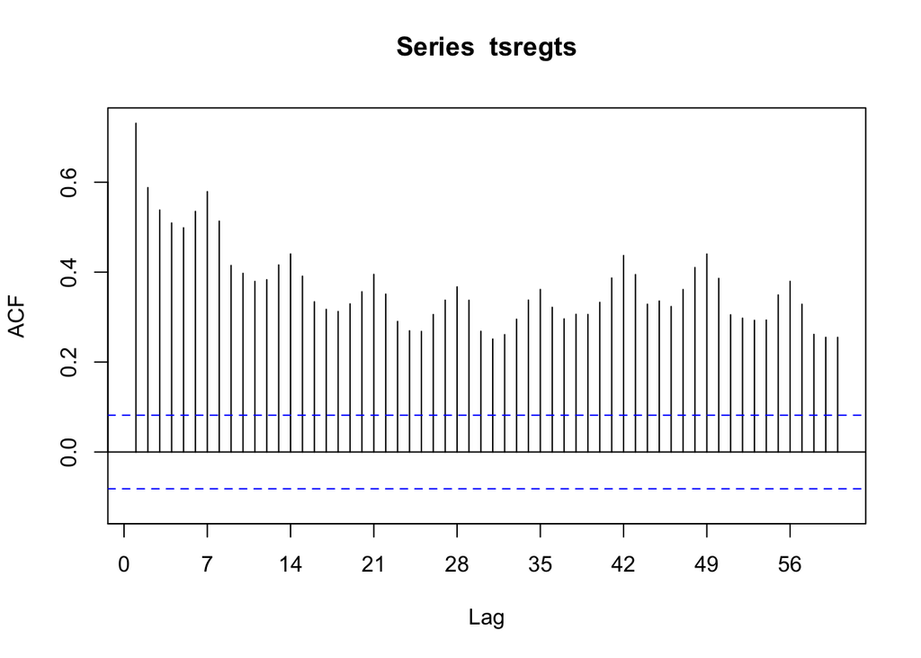

```r
Acf(tsregts, lag=60)
```

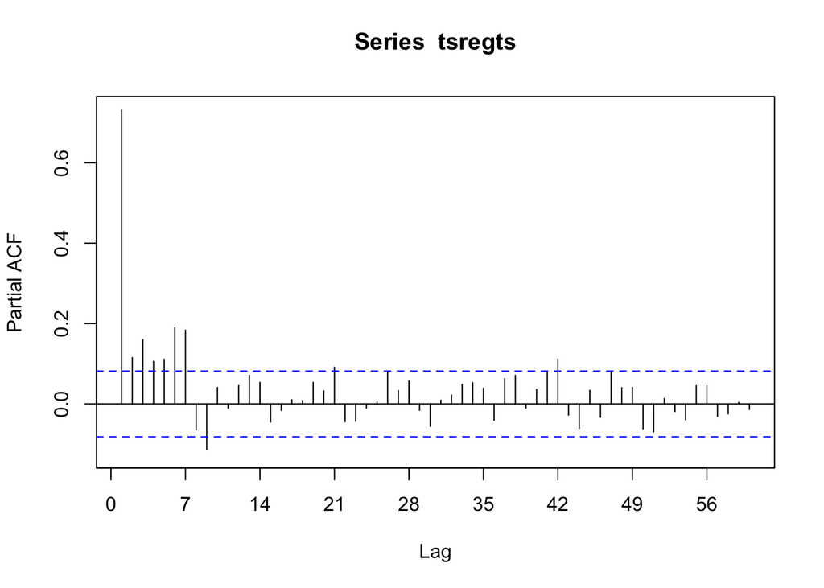

```r
Pacf(tsregts, lag=60)
```

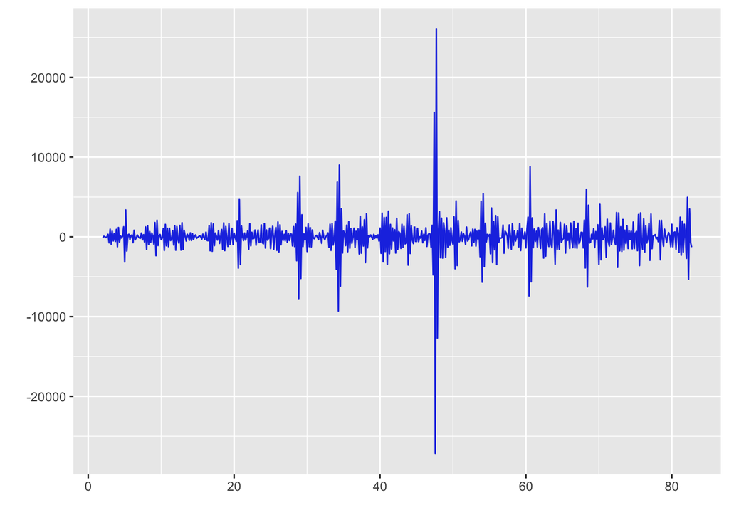

```r
#using diff to make data stationary --> already looking much better
tsdiff <- tsdf80f %>% group_by(order_purchase_timestamp) %>% summarise(sales_volume=sum(sales_volume))
tsdiffts <-  ts(tsdiff$sales_volume, frequency = 7)
diff1 <- diff(tsdiffts, differences = 7)
autoplot(diff1, ts.colour = "#213ee2")
```

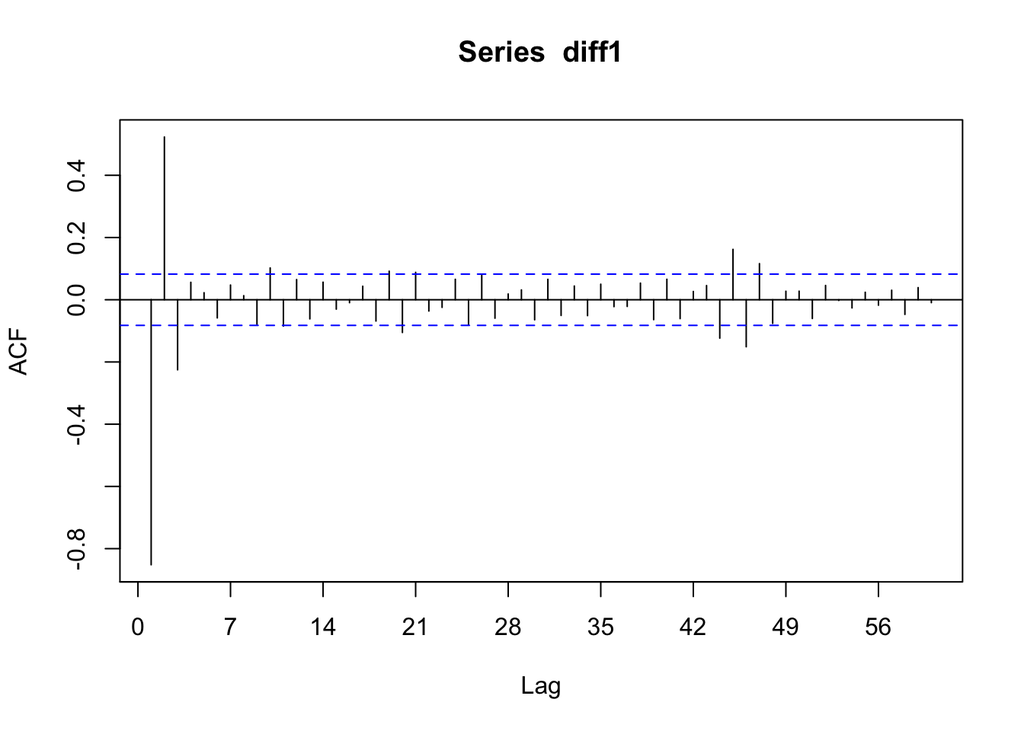

```r
Acf(diff1, lag=60)
```

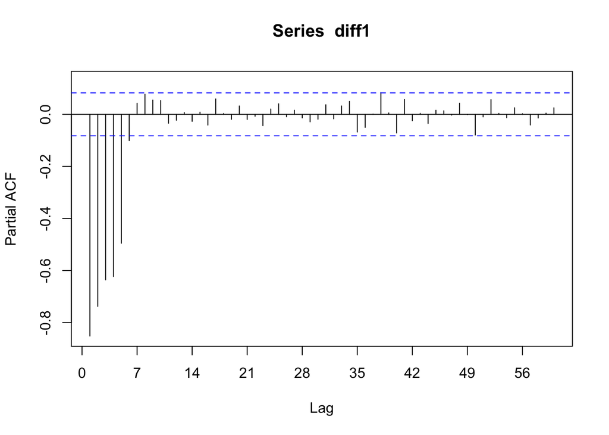

```r
Pacf(diff1, lag=60)
```

```r
adf.test(diff1, nlag = 1)
```

```
## Augmented Dickey-Fuller Test
## alternative: stationary
##
## Type 1: no drift no trend
##      lag ADF p.value
## [1,]   0 -84    0.01
## Type 2: with drift no trend
##      lag   ADF p.value
## [1,]   0 -83.9    0.01
## Type 3: with drift and trend
##      lag   ADF p.value
## [1,]   0 -83.9    0.01
## ----
## Note: in fact, p.value = 0.01 means p.value <= 0.01
```

## Training Arima Model

```r
tempdf <- tsdf80f %>% group_by(order_purchase_timestamp,day,month,dow) %>% summarise(sales_volume=sum(sales_volume))
#adding the holiday calendar information
hldy <- read.csv("~/Documents/ecommerce_sales_forecasting/holidaycalendarbrazil.csv", header=TRUE) %>% mutate(date = as.Date(as.character(Date), format = "%m/%d/%y"))

month <- as.character(tempdf$month)
dow <- as.character(tempdf$dow)
monthdum <- as.data.frame(model.matrix(~month-1))[,2:12]
dowdum <-as.data.frame(model.matrix(~dow-1))[,2:7]

tempdf <- tempdf %>% mutate(weekday =  ifelse(as.character( wday(order_purchase_timestamp, label=TRUE)) %in% c("Sun","Sat"), 0,1))
tempdf1 <- cbind(tempdf,monthdum,dowdum)

#merging the holiday information to the ts dataframe
merged_df <- left_join(tempdf1, hldy, by = c("order_purchase_timestamp"="date"), copy = FALSE)
merged_df['holiday']<- ifelse(is.na(merged_df$Date),0,1)

merged_df <- merged_df %>% select(-Date)
merged_df$product_category <- "all"

alltsb <- as_tsibble(merged_df, index = order_purchase_timestamp, key = product_category)
train <- merged_df %>% filter(order_purchase_timestamp < '2018-05-01')
test <- merged_df %>% filter(order_purchase_timestamp >= '2018-05-01')
traintsb <- as_tsibble(train, index = order_purchase_timestamp, key = product_category)
testtsb <- as_tsibble(test, index = order_purchase_timestamp, key = product_category)
```

### Analyzing individual models

The box test and residual analysis shows that the tuned Sarima follows correct assumptions and also is a better model than the auto arima. The manual/tuned Arima model shows better result since it is based on a thorough analysis on the PACF and ACF not just basing it off the log likelihood.

Additionally, the residual diagnostic indicated that the residuals are white noise, therefore the forecast is generally good. The Box Test results are not significant (i.e., the p-values are relatively large). Thus, we can conclude that the residuals are not distinguishable from a white noise series.

```r
traints <- ts(train$sales_volume, frequency = 7)
testts <- ts(test$sales_volume, frequency = 7)
ar_man <- arima(traints, order=c(4,1,2), seasonal= list(order=c(0,1,2), period=7))
ar_au <- auto.arima(traints)

print("Tuned Arima")
```

```
## [1] "Tuned Arima"
```

```r
summary(ar_man)
```

```
##
## Call:
## arima(x = traints, order = c(4, 1, 2), seasonal = list(order = c(0, 1, 2), period = 7))
##
## Coefficients:
##          ar1     ar2     ar3     ar4      ma1      ma2     sma1     sma2
##       0.3343  0.1198  0.0643  0.0628  -0.8680  -0.1320  -0.8543  -0.0937
## s.e.  0.8660  0.4094  0.0739  0.0772   0.8674   0.8673   0.0475   0.0472
##
## sigma^2 estimated as 4283:  log likelihood = -2661.33,  aic = 5340.66
##
## Training set error measures:
##                     ME     RMSE      MAE       MPE     MAPE      MASE
## Training set -1.970232 64.89831 30.93908 -8.690816 20.62269 0.7310602
##                      ACF1
## Training set -0.001975014
```

```r
Box.test(residuals(ar_man))
```

```
##
##  Box-Pierce test
##
## data:  residuals(ar_man)
## X-squared = 0.0018762, df = 1, p-value = 0.9655
```

```r
print("Auto Arima")
```

```
## [1] "Auto Arima"
```

```r
summary(ar_au)
```

```
## Series: traints
## ARIMA(1,1,1)(0,0,2)[7]
##
## Coefficients:
##          ar1      ma1    sma1    sma2
##       0.4919  -0.9662  0.1960  0.0920
## s.e.  0.0444   0.0143  0.0461  0.0441
##
## sigma^2 estimated as 4698:  log likelihood=-2709.11
## AIC=5428.21   AICc=5428.34   BIC=5449.08
##
## Training set error measures:
##                    ME     RMSE      MAE      MPE     MAPE      MASE        ACF1
## Training set 5.586571 68.18725 34.63436 -2.88942 22.70056 0.7604894 -0.02359192
```

```r
Box.test(residuals(ar_au))
```

```
##
##  Box-Pierce test
##
## data:  residuals(ar_au)
## X-squared = 0.26771, df = 1, p-value = 0.6049
```

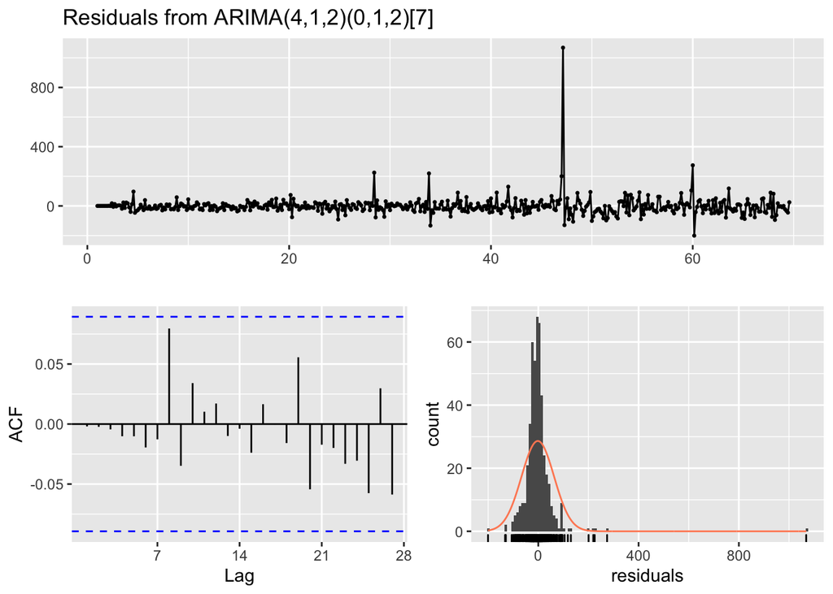

```
##
##  Ljung-Box test
##
## data:  Residuals from ARIMA(4,1,2)(0,1,2)[7]
## Q* = 4.916, df = 6, p-value = 0.5546
##
## Model df: 8.   Total lags used: 14
```

```r
checkresiduals((ar_man))
```